# Risk Factor Analysis

## Outcome Variable

**Outcome Variable:** ever_stunted

## Predictor Variables

**Intervention Variable:** single

**Adjustment Set:**

unadjusted

## Stratifying Variables

The analysis was stratified on these variable(s):

- agecat
- studyid
- country

## Data Summary

| agecat | studyid | country | single | ever_stunted | n_cell | n |
| --- | --- | --- | --- | --- | --- | --- |
| 0-6 months | ki0047075b-MAL-ED | BANGLADESH | 0 | 0 | 217 | 265 |
| 0-6 months | ki0047075b-MAL-ED | BANGLADESH | 0 | 1 | 48 | 265 |
| 0-6 months | ki0047075b-MAL-ED | BRAZIL | 0 | 0 | 180 | 233 |
| 0-6 months | ki0047075b-MAL-ED | BRAZIL | 0 | 1 | 17 | 233 |
| 0-6 months | ki0047075b-MAL-ED | BRAZIL | 1 | 0 | 28 | 233 |
| 0-6 months | ki0047075b-MAL-ED | BRAZIL | 1 | 1 | 8 | 233 |
| 0-6 months | ki0047075b-MAL-ED | INDIA | 0 | 0 | 208 | 249 |
| 0-6 months | ki0047075b-MAL-ED | INDIA | 0 | 1 | 41 | 249 |
| 0-6 months | ki0047075b-MAL-ED | NEPAL | 0 | 0 | 212 | 240 |
| 0-6 months | ki0047075b-MAL-ED | NEPAL | 0 | 1 | 28 | 240 |
| 0-6 months | ki0047075b-MAL-ED | PERU | 0 | 0 | 238 | 303 |
| 0-6 months | ki0047075b-MAL-ED | PERU | 0 | 1 | 30 | 303 |
| 0-6 months | ki0047075b-MAL-ED | PERU | 1 | 0 | 28 | 303 |
| 0-6 months | ki0047075b-MAL-ED | PERU | 1 | 1 | 7 | 303 |
| 0-6 months | ki0047075b-MAL-ED | SOUTH AFRICA | 0 | 0 | 160 | 314 |
| 0-6 months | ki0047075b-MAL-ED | SOUTH AFRICA | 0 | 1 | 16 | 314 |
| 0-6 months | ki0047075b-MAL-ED | SOUTH AFRICA | 1 | 0 | 120 | 314 |
| 0-6 months | ki0047075b-MAL-ED | SOUTH AFRICA | 1 | 1 | 18 | 314 |
| 0-6 months | ki0047075b-MAL-ED | TANZANIA, UNITED REPUBLIC OF | 0 | 0 | 210 | 262 |
| 0-6 months | ki0047075b-MAL-ED | TANZANIA, UNITED REPUBLIC OF | 0 | 1 | 42 | 262 |
| 0-6 months | ki0047075b-MAL-ED | TANZANIA, UNITED REPUBLIC OF | 1 | 0 | 9 | 262 |
| 0-6 months | ki0047075b-MAL-ED | TANZANIA, UNITED REPUBLIC OF | 1 | 1 | 1 | 262 |
| 0-6 months | ki1066203-TanzaniaChild2 | TANZANIA, UNITED REPUBLIC OF | 0 | 0 | 2004 | 2375 |
| 0-6 months | ki1066203-TanzaniaChild2 | TANZANIA, UNITED REPUBLIC OF | 0 | 1 | 147 | 2375 |
| 0-6 months | ki1066203-TanzaniaChild2 | TANZANIA, UNITED REPUBLIC OF | 1 | 0 | 211 | 2375 |
| 0-6 months | ki1066203-TanzaniaChild2 | TANZANIA, UNITED REPUBLIC OF | 1 | 1 | 13 | 2375 |
| 0-6 months | ki1112895-Guatemala BSC | GUATEMALA | 0 | 0 | 187 | 265 |
| 0-6 months | ki1112895-Guatemala BSC | GUATEMALA | 0 | 1 | 51 | 265 |
| 0-6 months | ki1112895-Guatemala BSC | GUATEMALA | 1 | 0 | 15 | 265 |
| 0-6 months | ki1112895-Guatemala BSC | GUATEMALA | 1 | 1 | 12 | 265 |

[output cut: 118 more lines]

The following strata were considered:

- agecat: 0-24 months, studyid: ki0047075b-MAL-ED, country: BANGLADESH
- agecat: 0-24 months, studyid: ki0047075b-MAL-ED, country: BRAZIL
- agecat: 0-24 months, studyid: ki0047075b-MAL-ED, country: INDIA
- agecat: 0-24 months, studyid: ki0047075b-MAL-ED, country: NEPAL
- agecat: 0-24 months, studyid: ki0047075b-MAL-ED, country: PERU
- agecat: 0-24 months, studyid: ki0047075b-MAL-ED, country: SOUTH AFRICA
- agecat: 0-24 months, studyid: ki0047075b-MAL-ED, country: TANZANIA, UNITED REPUBLIC OF
- agecat: 0-24 months, studyid: ki1066203-TanzaniaChild2, country: TANZANIA, UNITED REPUBLIC OF
- agecat: 0-24 months, studyid: ki1112895-Guatemala BSC, country: GUATEMALA
- agecat: 0-24 months, studyid: ki1119695-PROBIT, country: BELARUS
- agecat: 0-24 months, studyid: ki1126311-ZVITAMBO, country: ZIMBABWE
- agecat: 0-24 months, studyid: ki1135781-COHORTS, country: GUATEMALA
- agecat: 0-24 months, studyid: ki1135781-COHORTS, country: INDIA
- agecat: 0-24 months, studyid: ki1135781-COHORTS, country: PHILIPPINES
- agecat: 0-6 months, studyid: ki0047075b-MAL-ED, country: BANGLADESH
- agecat: 0-6 months, studyid: ki0047075b-MAL-ED, country: BRAZIL
- agecat: 0-6 months, studyid: ki0047075b-MAL-ED, country: INDIA
- agecat: 0-6 months, studyid: ki0047075b-MAL-ED, country: NEPAL
- agecat: 0-6 months, studyid: ki0047075b-MAL-ED, country: PERU
- agecat: 0-6 months, studyid: ki0047075b-MAL-ED, country: SOUTH AFRICA
- agecat: 0-6 months, studyid: ki0047075b-MAL-ED, country: TANZANIA, UNITED REPUBLIC OF
- agecat: 0-6 months, studyid: ki1066203-TanzaniaChild2, country: TANZANIA, UNITED REPUBLIC OF
- agecat: 0-6 months, studyid: ki1112895-Guatemala BSC, country: GUATEMALA
- agecat: 0-6 months, studyid: ki1119695-PROBIT, country: BELARUS
- agecat: 0-6 months, studyid: ki1126311-ZVITAMBO, country: ZIMBABWE
- agecat: 0-6 months, studyid: ki1135781-COHORTS, country: GUATEMALA
- agecat: 0-6 months, studyid: ki1135781-COHORTS, country: INDIA
- agecat: 0-6 months, studyid: ki1135781-COHORTS, country: PHILIPPINES
- agecat: 6-24 months, studyid: ki0047075b-MAL-ED, country: BANGLADESH
- agecat: 6-24 months, studyid: ki0047075b-MAL-ED, country: BRAZIL
- agecat: 6-24 months, studyid: ki0047075b-MAL-ED, country: INDIA
- agecat: 6-24 months, studyid: ki0047075b-MAL-ED, country: NEPAL
- agecat: 6-24 months, studyid: ki0047075b-MAL-ED, country: PERU
- agecat: 6-24 months, studyid: ki0047075b-MAL-ED, country: SOUTH AFRICA
- agecat: 6-24 months, studyid: ki0047075b-MAL-ED, country: TANZANIA, UNITED REPUBLIC OF
- agecat: 6-24 months, studyid: ki1066203-TanzaniaChild2, country: TANZANIA, UNITED REPUBLIC OF
- agecat: 6-24 months, studyid: ki1112895-Guatemala BSC, country: GUATEMALA
- agecat: 6-24 months, studyid: ki1119695-PROBIT, country: BELARUS
- agecat: 6-24 months, studyid: ki1126311-ZVITAMBO, country: ZIMBABWE
- agecat: 6-24 months, studyid: ki1135781-COHORTS, country: GUATEMALA
- agecat: 6-24 months, studyid: ki1135781-COHORTS, country: INDIA
- agecat: 6-24 months, studyid: ki1135781-COHORTS, country: PHILIPPINES

### Dropped Strata

Some strata were dropped due to rare outcomes:

- agecat: 0-6 months, studyid: ki0047075b-MAL-ED, country: TANZANIA, UNITED REPUBLIC OF
- agecat: 0-6 months, studyid: ki1135781-COHORTS, country: INDIA
- agecat: 6-24 months, studyid: ki0047075b-MAL-ED, country: BRAZIL
- agecat: 6-24 months, studyid: ki0047075b-MAL-ED, country: TANZANIA, UNITED REPUBLIC OF
- agecat: 0-24 months, studyid: ki0047075b-MAL-ED, country: TANZANIA, UNITED REPUBLIC OF
- agecat: 0-24 months, studyid: ki1135781-COHORTS, country: INDIA

## Methods Detail

We’re interested in the causal parameters $E[Y_a]$ for all values of $a \in \mathcal{A}$. These parameters represent the mean outcome if, possibly contrary to fact, we intervened to set all units to have $A=a$. Under the randomization and positivity assumptions, these are identified by the statistical parameters $\psi_a=E_W[E_{Y|A,W}(Y|A=a,W)]$. In addition, we’re interested in the mean of $Y$, $E[Y]$ under no intervention (the observed mean). We will estimate these parameters by using SuperLearner to fit the relevant likelihood factors – $E_{Y|A,W}(Y|A=a,W)$ and $p(A=a|W)$, and then updating our likelihood fit using a joint TMLE.

For unadjusted analyses ($W=\{\}$), initial likelihoods were estimated using Lrnr_glm to estimate the simple $E(Y|A)$ and Lrnr_mean to estimate $p(A)$. For adjusted analyses, a small library containing Lrnr_glmnet, Lrnr_xgboost, and Lrnr_mean was used.

Having estimated these parameters, we will then use the delta method to estimate relative risks and attributable risks relative to a prespecified baseline level of $A$.

[output not shown]

# Results Detail

## Results Plots

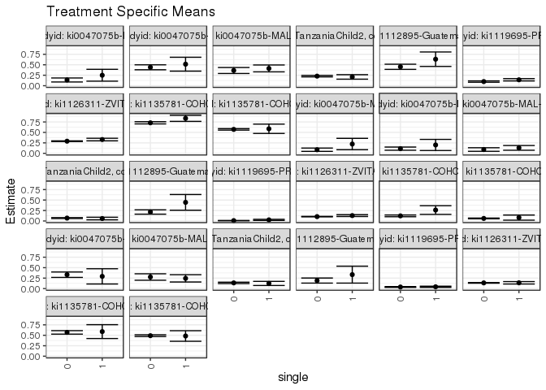

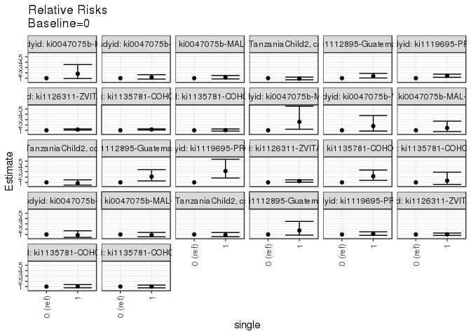

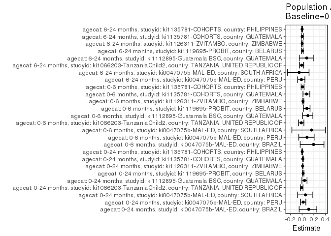

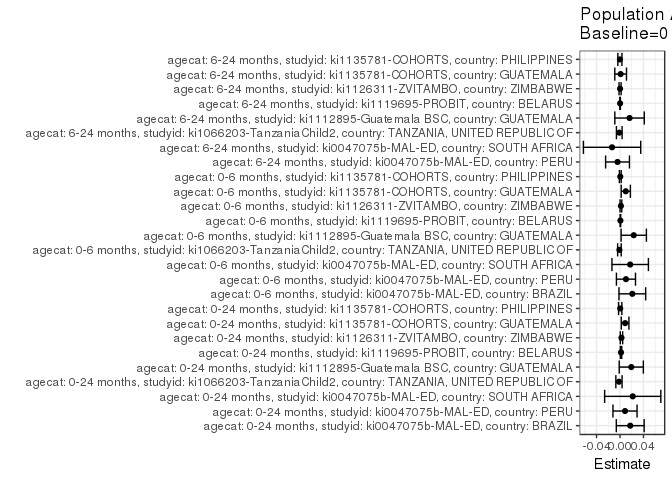

## Results Table

### Parameter: TSM

| agecat | studyid | country | intervention_level | baseline_level | estimate | ci_lower | ci_upper |
| --- | --- | --- | --- | --- | --- | --- | --- |
| 0-24 months | ki0047075b-MAL-ED | BRAZIL | 0 | NA | 0.1370558 | 0.0889288 | 0.1851829 |
| 0-24 months | ki0047075b-MAL-ED | BRAZIL | 1 | NA | 0.2500000 | 0.1082473 | 0.3917527 |
| 0-24 months | ki0047075b-MAL-ED | PERU | 0 | NA | 0.4402985 | 0.3807665 | 0.4998305 |
| 0-24 months | ki0047075b-MAL-ED | PERU | 1 | NA | 0.5142857 | 0.3484322 | 0.6801392 |
| 0-24 months | ki0047075b-MAL-ED | SOUTH AFRICA | 0 | NA | 0.3636364 | 0.2924543 | 0.4348185 |
| 0-24 months | ki0047075b-MAL-ED | SOUTH AFRICA | 1 | NA | 0.4130435 | 0.3307620 | 0.4953250 |
| 0-24 months | ki1066203-TanzaniaChild2 | TANZANIA, UNITED REPUBLIC OF | 0 | NA | 0.2287308 | 0.2109773 | 0.2464844 |
| 0-24 months | ki1066203-TanzaniaChild2 | TANZANIA, UNITED REPUBLIC OF | 1 | NA | 0.2098214 | 0.1564876 | 0.2631553 |
| 0-24 months | ki1112895-Guatemala BSC | GUATEMALA | 0 | NA | 0.4523810 | 0.3908192 | 0.5139427 |
| 0-24 months | ki1112895-Guatemala BSC | GUATEMALA | 1 | NA | 0.6333333 | 0.4605862 | 0.8060804 |
| 0-24 months | ki1119695-PROBIT | BELARUS | 0 | NA | 0.0988645 | 0.0828855 | 0.1148435 |
| 0-24 months | ki1119695-PROBIT | BELARUS | 1 | NA | 0.1414141 | 0.1142400 | 0.1685883 |
| 0-24 months | ki1126311-ZVITAMBO | ZIMBABWE | 0 | NA | 0.2901112 | 0.2823474 | 0.2978750 |
| 0-24 months | ki1126311-ZVITAMBO | ZIMBABWE | 1 | NA | 0.3295838 | 0.2986831 | 0.3604845 |
| 0-24 months | ki1135781-COHORTS | GUATEMALA | 0 | NA | 0.7294860 | 0.7033304 | 0.7556417 |
| 0-24 months | ki1135781-COHORTS | GUATEMALA | 1 | NA | 0.8367347 | 0.7635271 | 0.9099422 |
| 0-24 months | ki1135781-COHORTS | PHILIPPINES | 0 | NA | 0.5722052 | 0.5543272 | 0.5900832 |
| 0-24 months | ki1135781-COHORTS | PHILIPPINES | 1 | NA | 0.5866667 | 0.4752025 | 0.6981309 |
| 0-6 months | ki0047075b-MAL-ED | BRAZIL | 0 | NA | 0.0862944 | 0.0469989 | 0.1255900 |
| 0-6 months | ki0047075b-MAL-ED | BRAZIL | 1 | NA | 0.2222222 | 0.0861240 | 0.3583204 |
| 0-6 months | ki0047075b-MAL-ED | PERU | 0 | NA | 0.1119403 | 0.0741298 | 0.1497508 |
| 0-6 months | ki0047075b-MAL-ED | PERU | 1 | NA | 0.2000000 | 0.0672630 | 0.3327370 |
| 0-6 months | ki0047075b-MAL-ED | SOUTH AFRICA | 0 | NA | 0.0909091 | 0.0483697 | 0.1334485 |
| 0-6 months | ki0047075b-MAL-ED | SOUTH AFRICA | 1 | NA | 0.1304348 | 0.0741554 | 0.1867141 |
| 0-6 months | ki1066203-TanzaniaChild2 | TANZANIA, UNITED REPUBLIC OF | 0 | NA | 0.0683403 | 0.0576747 | 0.0790059 |
| 0-6 months | ki1066203-TanzaniaChild2 | TANZANIA, UNITED REPUBLIC OF | 1 | NA | 0.0580357 | 0.0274104 | 0.0886610 |
| 0-6 months | ki1112895-Guatemala BSC | GUATEMALA | 0 | NA | 0.2142857 | 0.1620570 | 0.2665145 |
| 0-6 months | ki1112895-Guatemala BSC | GUATEMALA | 1 | NA | 0.4444444 | 0.2566600 | 0.6322289 |
| 0-6 months | ki1119695-PROBIT | BELARUS | 0 | NA | 0.0083333 | 0.0052719 | 0.0113948 |
| 0-6 months | ki1119695-PROBIT | BELARUS | 1 | NA | 0.0259740 | 0.0129646 | 0.0389835 |
| 0-6 months | ki1126311-ZVITAMBO | ZIMBABWE | 0 | NA | 0.1037693 | 0.0985480 | 0.1089905 |
| 0-6 months | ki1126311-ZVITAMBO | ZIMBABWE | 1 | NA | 0.1285231 | 0.1064979 | 0.1505483 |
| 0-6 months | ki1135781-COHORTS | GUATEMALA | 0 | NA | 0.1215470 | 0.1002470 | 0.1428469 |
| 0-6 months | ki1135781-COHORTS | GUATEMALA | 1 | NA | 0.2608696 | 0.1572077 | 0.3645314 |
| 0-6 months | ki1135781-COHORTS | PHILIPPINES | 0 | NA | 0.0601427 | 0.0515516 | 0.0687338 |
| 0-6 months | ki1135781-COHORTS | PHILIPPINES | 1 | NA | 0.0800000 | 0.0185915 | 0.1414085 |
| 6-24 months | ki0047075b-MAL-ED | PERU | 0 | NA | 0.3317073 | 0.2671148 | 0.3962999 |
| 6-24 months | ki0047075b-MAL-ED | PERU | 1 | NA | 0.2916667 | 0.1094219 | 0.4739114 |
| 6-24 months | ki0047075b-MAL-ED | SOUTH AFRICA | 0 | NA | 0.2769231 | 0.1998292 | 0.3540169 |
| 6-24 months | ki0047075b-MAL-ED | SOUTH AFRICA | 1 | NA | 0.2446809 | 0.1575803 | 0.3317814 |
| 6-24 months | ki1066203-TanzaniaChild2 | TANZANIA, UNITED REPUBLIC OF | 0 | NA | 0.1359807 | 0.1194972 | 0.1524643 |
| 6-24 months | ki1066203-TanzaniaChild2 | TANZANIA, UNITED REPUBLIC OF | 1 | NA | 0.1228070 | 0.0735999 | 0.1720141 |
| 6-24 months | ki1112895-Guatemala BSC | GUATEMALA | 0 | NA | 0.1913580 | 0.1306170 | 0.2520990 |
| 6-24 months | ki1112895-Guatemala BSC | GUATEMALA | 1 | NA | 0.3333333 | 0.1311609 | 0.5355058 |
| 6-24 months | ki1119695-PROBIT | BELARUS | 0 | NA | 0.0378420 | 0.0283348 | 0.0473492 |
| 6-24 months | ki1119695-PROBIT | BELARUS | 1 | NA | 0.0424886 | 0.0284661 | 0.0565112 |
| 6-24 months | ki1126311-ZVITAMBO | ZIMBABWE | 0 | NA | 0.1360046 | 0.1288155 | 0.1431936 |
| 6-24 months | ki1126311-ZVITAMBO | ZIMBABWE | 1 | NA | 0.1381215 | 0.1090997 | 0.1671434 |
| 6-24 months | ki1135781-COHORTS | GUATEMALA | 0 | NA | 0.5693431 | 0.5278492 | 0.6108369 |
| 6-24 months | ki1135781-COHORTS | GUATEMALA | 1 | NA | 0.5882353 | 0.4226651 | 0.7538055 |
| 6-24 months | ki1135781-COHORTS | PHILIPPINES | 0 | NA | 0.4903981 | 0.4691883 | 0.5116080 |
| 6-24 months | ki1135781-COHORTS | PHILIPPINES | 1 | NA | 0.4833333 | 0.3568597 | 0.6098070 |

### Parameter: E(Y)

| agecat | studyid | country | intervention_level | baseline_level | estimate | ci_lower | ci_upper |
| --- | --- | --- | --- | --- | --- | --- | --- |
| 0-24 months | ki0047075b-MAL-ED | BRAZIL | NA | NA | 0.1545064 | 0.1079979 | 0.2010150 |
| 0-24 months | ki0047075b-MAL-ED | PERU | NA | NA | 0.4488449 | 0.3927492 | 0.5049406 |
| 0-24 months | ki0047075b-MAL-ED | SOUTH AFRICA | NA | NA | 0.3853503 | 0.3314343 | 0.4392663 |
| 0-24 months | ki1066203-TanzaniaChild2 | TANZANIA, UNITED REPUBLIC OF | NA | NA | 0.2269474 | 0.2100983 | 0.2437964 |
| 0-24 months | ki1112895-Guatemala BSC | GUATEMALA | NA | NA | 0.4716312 | 0.4132646 | 0.5299979 |
| 0-24 months | ki1119695-PROBIT | BELARUS | NA | NA | 0.1006096 | 0.0848963 | 0.1163228 |
| 0-24 months | ki1126311-ZVITAMBO | ZIMBABWE | NA | NA | 0.2926151 | 0.2850825 | 0.3001476 |
| 0-24 months | ki1135781-COHORTS | GUATEMALA | NA | NA | 0.7381939 | 0.7133826 | 0.7630052 |
| 0-24 months | ki1135781-COHORTS | PHILIPPINES | NA | NA | 0.5725646 | 0.5549120 | 0.5902172 |
| 0-6 months | ki0047075b-MAL-ED | BRAZIL | NA | NA | 0.1072961 | 0.0674717 | 0.1471206 |
| 0-6 months | ki0047075b-MAL-ED | PERU | NA | NA | 0.1221122 | 0.0851852 | 0.1590392 |
| 0-6 months | ki0047075b-MAL-ED | SOUTH AFRICA | NA | NA | 0.1082803 | 0.0738560 | 0.1427045 |
| 0-6 months | ki1066203-TanzaniaChild2 | TANZANIA, UNITED REPUBLIC OF | NA | NA | 0.0673684 | 0.0572854 | 0.0774514 |
| 0-6 months | ki1112895-Guatemala BSC | GUATEMALA | NA | NA | 0.2377358 | 0.1863852 | 0.2890865 |
| 0-6 months | ki1119695-PROBIT | BELARUS | NA | NA | 0.0090570 | 0.0059070 | 0.0122070 |
| 0-6 months | ki1126311-ZVITAMBO | ZIMBABWE | NA | NA | 0.1053384 | 0.1002517 | 0.1104250 |
| 0-6 months | ki1135781-COHORTS | GUATEMALA | NA | NA | 0.1314168 | 0.1101882 | 0.1526455 |
| 0-6 months | ki1135781-COHORTS | PHILIPPINES | NA | NA | 0.0606362 | 0.0521200 | 0.0691523 |
| 6-24 months | ki0047075b-MAL-ED | PERU | NA | NA | 0.3275109 | 0.2665942 | 0.3884276 |
| 6-24 months | ki0047075b-MAL-ED | SOUTH AFRICA | NA | NA | 0.2633929 | 0.2055812 | 0.3212045 |
| 6-24 months | ki1066203-TanzaniaChild2 | TANZANIA, UNITED REPUBLIC OF | NA | NA | 0.1347518 | 0.1191159 | 0.1503877 |
| 6-24 months | ki1112895-Guatemala BSC | GUATEMALA | NA | NA | 0.2076503 | 0.1487202 | 0.2665804 |
| 6-24 months | ki1119695-PROBIT | BELARUS | NA | NA | 0.0380298 | 0.0285924 | 0.0474672 |
| 6-24 months | ki1126311-ZVITAMBO | ZIMBABWE | NA | NA | 0.1361285 | 0.1291503 | 0.1431067 |
| 6-24 months | ki1135781-COHORTS | GUATEMALA | NA | NA | 0.5704467 | 0.5301958 | 0.6106977 |
| 6-24 months | ki1135781-COHORTS | PHILIPPINES | NA | NA | 0.4902050 | 0.4692872 | 0.5111228 |

### Parameter: RR

| agecat | studyid | country | intervention_level | baseline_level | estimate | ci_lower | ci_upper |
| --- | --- | --- | --- | --- | --- | --- | --- |
| 0-24 months | ki0047075b-MAL-ED | BRAZIL | 0 | 0 | 1.0000000 | 1.0000000 | 1.000000 |
| 0-24 months | ki0047075b-MAL-ED | BRAZIL | 1 | 0 | 1.8240741 | 0.9362562 | 3.553777 |
| 0-24 months | ki0047075b-MAL-ED | PERU | 0 | 0 | 1.0000000 | 1.0000000 | 1.000000 |
| 0-24 months | ki0047075b-MAL-ED | PERU | 1 | 0 | 1.1680387 | 0.8233584 | 1.657012 |
| 0-24 months | ki0047075b-MAL-ED | SOUTH AFRICA | 0 | 0 | 1.0000000 | 1.0000000 | 1.000000 |
| 0-24 months | ki0047075b-MAL-ED | SOUTH AFRICA | 1 | 0 | 1.1358696 | 0.8590827 | 1.501834 |
| 0-24 months | ki1066203-TanzaniaChild2 | TANZANIA, UNITED REPUBLIC OF | 0 | 0 | 1.0000000 | 1.0000000 | 1.000000 |
| 0-24 months | ki1066203-TanzaniaChild2 | TANZANIA, UNITED REPUBLIC OF | 1 | 0 | 0.9173291 | 0.7032362 | 1.196600 |
| 0-24 months | ki1112895-Guatemala BSC | GUATEMALA | 0 | 0 | 1.0000000 | 1.0000000 | 1.000000 |
| 0-24 months | ki1112895-Guatemala BSC | GUATEMALA | 1 | 0 | 1.4000000 | 1.0321571 | 1.898936 |
| 0-24 months | ki1119695-PROBIT | BELARUS | 0 | 0 | 1.0000000 | 1.0000000 | 1.000000 |
| 0-24 months | ki1119695-PROBIT | BELARUS | 1 | 0 | 1.4303837 | 1.1685319 | 1.750913 |
| 0-24 months | ki1126311-ZVITAMBO | ZIMBABWE | 0 | 0 | 1.0000000 | 1.0000000 | 1.000000 |
| 0-24 months | ki1126311-ZVITAMBO | ZIMBABWE | 1 | 0 | 1.1360601 | 1.0305216 | 1.252407 |
| 0-24 months | ki1135781-COHORTS | GUATEMALA | 0 | 0 | 1.0000000 | 1.0000000 | 1.000000 |
| 0-24 months | ki1135781-COHORTS | GUATEMALA | 1 | 0 | 1.1470195 | 1.0435340 | 1.260767 |
| 0-24 months | ki1135781-COHORTS | PHILIPPINES | 0 | 0 | 1.0000000 | 1.0000000 | 1.000000 |
| 0-24 months | ki1135781-COHORTS | PHILIPPINES | 1 | 0 | 1.0252732 | 0.8457017 | 1.242974 |
| 0-6 months | ki0047075b-MAL-ED | BRAZIL | 0 | 0 | 1.0000000 | 1.0000000 | 1.000000 |
| 0-6 months | ki0047075b-MAL-ED | BRAZIL | 1 | 0 | 2.5751634 | 1.2004941 | 5.523947 |
| 0-6 months | ki0047075b-MAL-ED | PERU | 0 | 0 | 1.0000000 | 1.0000000 | 1.000000 |
| 0-6 months | ki0047075b-MAL-ED | PERU | 1 | 0 | 1.7866667 | 0.8484516 | 3.762357 |
| 0-6 months | ki0047075b-MAL-ED | SOUTH AFRICA | 0 | 0 | 1.0000000 | 1.0000000 | 1.000000 |
| 0-6 months | ki0047075b-MAL-ED | SOUTH AFRICA | 1 | 0 | 1.4347826 | 0.7592023 | 2.711532 |
| 0-6 months | ki1066203-TanzaniaChild2 | TANZANIA, UNITED REPUBLIC OF | 0 | 0 | 1.0000000 | 1.0000000 | 1.000000 |
| 0-6 months | ki1066203-TanzaniaChild2 | TANZANIA, UNITED REPUBLIC OF | 1 | 0 | 0.8492165 | 0.4898122 | 1.472337 |
| 0-6 months | ki1112895-Guatemala BSC | GUATEMALA | 0 | 0 | 1.0000000 | 1.0000000 | 1.000000 |
| 0-6 months | ki1112895-Guatemala BSC | GUATEMALA | 1 | 0 | 2.0740741 | 1.2734617 | 3.378023 |
| 0-6 months | ki1119695-PROBIT | BELARUS | 0 | 0 | 1.0000000 | 1.0000000 | 1.000000 |
| 0-6 months | ki1119695-PROBIT | BELARUS | 1 | 0 | 3.1168831 | 1.8200939 | 5.337615 |
| 0-6 months | ki1126311-ZVITAMBO | ZIMBABWE | 0 | 0 | 1.0000000 | 1.0000000 | 1.000000 |
| 0-6 months | ki1126311-ZVITAMBO | ZIMBABWE | 1 | 0 | 1.2385470 | 1.0359650 | 1.480744 |
| 0-6 months | ki1135781-COHORTS | GUATEMALA | 0 | 0 | 1.0000000 | 1.0000000 | 1.000000 |
| 0-6 months | ki1135781-COHORTS | GUATEMALA | 1 | 0 | 2.1462451 | 1.3901680 | 3.313533 |
| 0-6 months | ki1135781-COHORTS | PHILIPPINES | 0 | 0 | 1.0000000 | 1.0000000 | 1.000000 |
| 0-6 months | ki1135781-COHORTS | PHILIPPINES | 1 | 0 | 1.3301695 | 0.6092799 | 2.904003 |
| 6-24 months | ki0047075b-MAL-ED | PERU | 0 | 0 | 1.0000000 | 1.0000000 | 1.000000 |
| 6-24 months | ki0047075b-MAL-ED | PERU | 1 | 0 | 0.8792892 | 0.4569778 | 1.691875 |
| 6-24 months | ki0047075b-MAL-ED | SOUTH AFRICA | 0 | 0 | 1.0000000 | 1.0000000 | 1.000000 |
| 6-24 months | ki0047075b-MAL-ED | SOUTH AFRICA | 1 | 0 | 0.8835697 | 0.5623139 | 1.388362 |
| 6-24 months | ki1066203-TanzaniaChild2 | TANZANIA, UNITED REPUBLIC OF | 0 | 0 | 1.0000000 | 1.0000000 | 1.000000 |
| 6-24 months | ki1066203-TanzaniaChild2 | TANZANIA, UNITED REPUBLIC OF | 1 | 0 | 0.9031206 | 0.5942112 | 1.372621 |
| 6-24 months | ki1112895-Guatemala BSC | GUATEMALA | 0 | 0 | 1.0000000 | 1.0000000 | 1.000000 |
| 6-24 months | ki1112895-Guatemala BSC | GUATEMALA | 1 | 0 | 1.7419355 | 0.8784811 | 3.454075 |
| 6-24 months | ki1119695-PROBIT | BELARUS | 0 | 0 | 1.0000000 | 1.0000000 | 1.000000 |
| 6-24 months | ki1119695-PROBIT | BELARUS | 1 | 0 | 1.1227905 | 0.8411160 | 1.498793 |
| 6-24 months | ki1126311-ZVITAMBO | ZIMBABWE | 0 | 0 | 1.0000000 | 1.0000000 | 1.000000 |
| 6-24 months | ki1126311-ZVITAMBO | ZIMBABWE | 1 | 0 | 1.0155654 | 0.8177328 | 1.261259 |
| 6-24 months | ki1135781-COHORTS | GUATEMALA | 0 | 0 | 1.0000000 | 1.0000000 | 1.000000 |
| 6-24 months | ki1135781-COHORTS | GUATEMALA | 1 | 0 | 1.0331825 | 0.7725120 | 1.381812 |
| 6-24 months | ki1135781-COHORTS | PHILIPPINES | 0 | 0 | 1.0000000 | 1.0000000 | 1.000000 |
| 6-24 months | ki1135781-COHORTS | PHILIPPINES | 1 | 0 | 0.9855938 | 0.7559872 | 1.284936 |

### Parameter: PAR

| agecat | studyid | country | intervention_level | baseline_level | estimate | ci_lower | ci_upper |
| --- | --- | --- | --- | --- | --- | --- | --- |
| 0-24 months | ki0047075b-MAL-ED | BRAZIL | 0 | NA | 0.0174506 | -0.0062680 | 0.0411692 |
| 0-24 months | ki0047075b-MAL-ED | PERU | 0 | NA | 0.0085464 | -0.0119824 | 0.0290752 |
| 0-24 months | ki0047075b-MAL-ED | SOUTH AFRICA | 0 | NA | 0.0217140 | -0.0261791 | 0.0696070 |
| 0-24 months | ki1066203-TanzaniaChild2 | TANZANIA, UNITED REPUBLIC OF | 0 | NA | -0.0017835 | -0.0070897 | 0.0035228 |
| 0-24 months | ki1112895-Guatemala BSC | GUATEMALA | 0 | NA | 0.0192503 | -0.0013209 | 0.0398214 |
| 0-24 months | ki1119695-PROBIT | BELARUS | 0 | NA | 0.0017451 | 0.0005422 | 0.0029480 |
| 0-24 months | ki1126311-ZVITAMBO | ZIMBABWE | 0 | NA | 0.0025038 | 0.0004765 | 0.0045311 |
| 0-24 months | ki1135781-COHORTS | GUATEMALA | 0 | NA | 0.0087078 | 0.0021830 | 0.0152327 |
| 0-24 months | ki1135781-COHORTS | PHILIPPINES | 0 | NA | 0.0003594 | -0.0024472 | 0.0031659 |
| 0-6 months | ki0047075b-MAL-ED | BRAZIL | 0 | NA | 0.0210017 | -0.0017800 | 0.0437834 |
| 0-6 months | ki0047075b-MAL-ED | PERU | 0 | NA | 0.0101719 | -0.0060837 | 0.0264275 |
| 0-6 months | ki0047075b-MAL-ED | SOUTH AFRICA | 0 | NA | 0.0173712 | -0.0137099 | 0.0484522 |
| 0-6 months | ki1066203-TanzaniaChild2 | TANZANIA, UNITED REPUBLIC OF | 0 | NA | -0.0009719 | -0.0040329 | 0.0020891 |
| 0-6 months | ki1112895-Guatemala BSC | GUATEMALA | 0 | NA | 0.0234501 | 0.0018883 | 0.0450120 |
| 0-6 months | ki1119695-PROBIT | BELARUS | 0 | NA | 0.0007237 | 0.0002003 | 0.0012470 |
| 0-6 months | ki1126311-ZVITAMBO | ZIMBABWE | 0 | NA | 0.0015691 | 0.0001308 | 0.0030074 |
| 0-6 months | ki1135781-COHORTS | GUATEMALA | 0 | NA | 0.0098699 | 0.0020437 | 0.0176961 |
| 0-6 months | ki1135781-COHORTS | PHILIPPINES | 0 | NA | 0.0004935 | -0.0010514 | 0.0020383 |
| 6-24 months | ki0047075b-MAL-ED | PERU | 0 | NA | -0.0041964 | -0.0245229 | 0.0161301 |
| 6-24 months | ki0047075b-MAL-ED | SOUTH AFRICA | 0 | NA | -0.0135302 | -0.0623871 | 0.0353266 |
| 6-24 months | ki1066203-TanzaniaChild2 | TANZANIA, UNITED REPUBLIC OF | 0 | NA | -0.0012290 | -0.0060734 | 0.0036154 |
| 6-24 months | ki1112895-Guatemala BSC | GUATEMALA | 0 | NA | 0.0162922 | -0.0088086 | 0.0413930 |
| 6-24 months | ki1119695-PROBIT | BELARUS | 0 | NA | 0.0001878 | -0.0003078 | 0.0006834 |
| 6-24 months | ki1126311-ZVITAMBO | ZIMBABWE | 0 | NA | 0.0001239 | -0.0016260 | 0.0018738 |
| 6-24 months | ki1135781-COHORTS | GUATEMALA | 0 | NA | 0.0011037 | -0.0088744 | 0.0110818 |
| 6-24 months | ki1135781-COHORTS | PHILIPPINES | 0 | NA | -0.0001931 | -0.0036989 | 0.0033126 |

### Parameter: PAF

| agecat | studyid | country | intervention_level | baseline_level | estimate | ci_lower | ci_upper |
| --- | --- | --- | --- | --- | --- | --- | --- |
| 0-24 months | ki0047075b-MAL-ED | BRAZIL | 0 | NA | 0.1129442 | -0.0516056 | 0.2517460 |
| 0-24 months | ki0047075b-MAL-ED | PERU | 0 | NA | 0.0190408 | -0.0278178 | 0.0637632 |
| 0-24 months | ki0047075b-MAL-ED | SOUTH AFRICA | 0 | NA | 0.0563486 | -0.0765440 | 0.1728365 |
| 0-24 months | ki1066203-TanzaniaChild2 | TANZANIA, UNITED REPUBLIC OF | 0 | NA | -0.0078584 | -0.0315097 | 0.0152505 |
| 0-24 months | ki1112895-Guatemala BSC | GUATEMALA | 0 | NA | 0.0408163 | -0.0040252 | 0.0836551 |
| 0-24 months | ki1119695-PROBIT | BELARUS | 0 | NA | 0.0173452 | 0.0045247 | 0.0300007 |
| 0-24 months | ki1126311-ZVITAMBO | ZIMBABWE | 0 | NA | 0.0085567 | 0.0016049 | 0.0154601 |
| 0-24 months | ki1135781-COHORTS | GUATEMALA | 0 | NA | 0.0117962 | 0.0028766 | 0.0206359 |
| 0-24 months | ki1135781-COHORTS | PHILIPPINES | 0 | NA | 0.0006277 | -0.0042861 | 0.0055174 |
| 0-6 months | ki0047075b-MAL-ED | BRAZIL | 0 | NA | 0.1957360 | -0.0339605 | 0.3744050 |
| 0-6 months | ki0047075b-MAL-ED | PERU | 0 | NA | 0.0832997 | -0.0579063 | 0.2056580 |
| 0-6 months | ki0047075b-MAL-ED | SOUTH AFRICA | 0 | NA | 0.1604278 | -0.1766897 | 0.4009623 |
| 0-6 months | ki1066203-TanzaniaChild2 | TANZANIA, UNITED REPUBLIC OF | 0 | NA | -0.0144264 | -0.0608503 | 0.0299659 |
| 0-6 months | ki1112895-Guatemala BSC | GUATEMALA | 0 | NA | 0.0986395 | 0.0044409 | 0.1839250 |
| 0-6 months | ki1119695-PROBIT | BELARUS | 0 | NA | 0.0799020 | 0.0205454 | 0.1356614 |
| 0-6 months | ki1126311-ZVITAMBO | ZIMBABWE | 0 | NA | 0.0148960 | 0.0011614 | 0.0284417 |
| 0-6 months | ki1135781-COHORTS | GUATEMALA | 0 | NA | 0.0751036 | 0.0145477 | 0.1319383 |
| 0-6 months | ki1135781-COHORTS | PHILIPPINES | 0 | NA | 0.0081382 | -0.0176464 | 0.0332695 |
| 6-24 months | ki0047075b-MAL-ED | PERU | 0 | NA | -0.0128130 | -0.0768169 | 0.0473867 |
| 6-24 months | ki0047075b-MAL-ED | SOUTH AFRICA | 0 | NA | -0.0513690 | -0.2541270 | 0.1186086 |
| 6-24 months | ki1066203-TanzaniaChild2 | TANZANIA, UNITED REPUBLIC OF | 0 | NA | -0.0091203 | -0.0457079 | 0.0261872 |
| 6-24 months | ki1112895-Guatemala BSC | GUATEMALA | 0 | NA | 0.0784600 | -0.0494930 | 0.1908132 |
| 6-24 months | ki1119695-PROBIT | BELARUS | 0 | NA | 0.0049389 | -0.0083784 | 0.0180804 |
| 6-24 months | ki1126311-ZVITAMBO | ZIMBABWE | 0 | NA | 0.0009101 | -0.0120275 | 0.0136824 |
| 6-24 months | ki1135781-COHORTS | GUATEMALA | 0 | NA | 0.0019347 | -0.0157121 | 0.0192750 |
| 6-24 months | ki1135781-COHORTS | PHILIPPINES | 0 | NA | -0.0003939 | -0.0075712 | 0.0067322 |